None

# Machine Learning Using Automated Hyperparameter Optimization and Scoring Metrics for Classifying Cheese by Fat Content

### by Batool Azim

#### August 2023

# Introduction

The cheese market in Canada is substantial, with reported revenues of 7.3 billion US dollars for this year alone (Statista, 2023). The upcoming years are projected to exhibit an annual growth rate of 7.97% until 2028.

Cheese is consumed in all provinces of Canada and is part of the Canadian population’s diet. Canada’s food guide promotes choosing lower-fat cheeses among milk and dairy products of protein foods. Additionally, Cheese.com identifies a total of 1,830 specialty cheeses. The extensive variety and diverse categories of cheeses render the fat classification process quite challenging. This is where a machine learning model can step in to facilitate the process.

The purpose of this paper is to develop a model that reduces instances where cheeses with higher fat content are incorrectly classified as lower fat. This focus is particularly aimed at individuals who monitor their saturated fat intake, aiming to keep it minimal. Misclassifying a higher fat cheese as lower fat holds greater drawbacks for this specific population. The classification model I intend to create for this project will effectively differentiate between "higher fat" as a positive label and "lower fat" as a negative label.

# Exploratory Data Analysis

```
(1042, 12)
```

|  | ManufacturerProvCode | ManufacturingTypeEn | MoisturePercent | FlavourEn | CharacteristicsEn | Organic | CategoryTypeEn | MilkTypeEn | MilkTreatmentTypeEn | RindTypeEn | CheeseName | FatLevel |
| --- | --- | --- | --- | --- | --- | --- | --- | --- | --- | --- | --- | --- |
| 0 | NB | Farmstead | 47.0 | Sharp, lactic | Uncooked | 0 | Firm Cheese | Ewe | Raw Milk | Washed Rind | Sieur de Duplessis (Le) | lower fat |
| 1 | NB | Farmstead | 47.9 | Sharp, lactic, lightly caramelized | Uncooked | 0 | Semi-soft Cheese | Cow | Raw Milk | Washed Rind | Tomme Le Champ Doré | lower fat |
| 2 | ON | Industrial | 54.0 | Mild, tangy, and fruity | Pressed and cooked cheese, pasta filata, inter... | 0 | Firm Cheese | Cow | Pasteurized | NaN | Provolone Sette Fette (Tre-Stelle) | lower fat |
| 3 | NB | Farmstead | 47.0 | Sharp with fruity notes and a hint of wild honey | NaN | 0 | Veined Cheeses | Cow | Raw Milk | NaN | Geai Bleu (Le) | lower fat |
| 4 | NB | Farmstead | 49.4 | Softer taste | NaN | 1 | Semi-soft Cheese | Cow | Raw Milk | Washed Rind | Gamin (Le) | lower fat |

```
(729, 12)
```

There are 729 records in “train_df.”

|  | ManufacturerProvCode | ManufacturingTypeEn | MoisturePercent | FlavourEn | CharacteristicsEn | Organic | CategoryTypeEn | MilkTypeEn | MilkTreatmentTypeEn | RindTypeEn | CheeseName | FatLevel |
| --- | --- | --- | --- | --- | --- | --- | --- | --- | --- | --- | --- | --- |
| count | 729 | 729 | 721.000000 | 567 | 449 | 729.000000 | 712 | 728 | 684 | 505 | 729 | 729 |
| unique | 8 | 3 | NaN | 457 | 392 | NaN | 6 | 8 | 3 | 4 | 728 | 2 |
| top | QC | Industrial | NaN | Mild | Creamy | NaN | Firm Cheese | Cow | Pasteurized | No Rind | Ménestrel (Le) | lower fat |
| freq | 561 | 310 | NaN | 45 | 12 | NaN | 252 | 521 | 552 | 289 | 2 | 471 |
| mean | NaN | NaN | 47.144799 | NaN | NaN | 0.089163 | NaN | NaN | NaN | NaN | NaN | NaN |
| std | NaN | NaN | 9.452688 | NaN | NaN | 0.285175 | NaN | NaN | NaN | NaN | NaN | NaN |
| min | NaN | NaN | 12.000000 | NaN | NaN | 0.000000 | NaN | NaN | NaN | NaN | NaN | NaN |
| 25% | NaN | NaN | 40.000000 | NaN | NaN | 0.000000 | NaN | NaN | NaN | NaN | NaN | NaN |
| 50% | NaN | NaN | 46.000000 | NaN | NaN | 0.000000 | NaN | NaN | NaN | NaN | NaN | NaN |
| 75% | NaN | NaN | 52.000000 | NaN | NaN | 0.000000 | NaN | NaN | NaN | NaN | NaN | NaN |
| max | NaN | NaN | 92.000000 | NaN | NaN | 1.000000 | NaN | NaN | NaN | NaN | NaN | NaN |

The describe method yields intriguing initial observations. The key findings are as follows:

- There is a significant diversity of 728 unique cheese names.
- Quebec stands out as the primary cheese producer, accounting for 561 out of the total 729 records.
- Cow's milk ranks as the predominant source for cheese, constituting 521 out of the 728 records spanning eight categories.

```
<class 'pandas.core.frame.DataFrame'>
Index: 729 entries, 116 to 864
Data columns (total 12 columns):
 #   Column                Non-Null Count  Dtype
---  ------                --------------  -----
 0   ManufacturerProvCode  729 non-null    object
 1   ManufacturingTypeEn   729 non-null    object
 2   MoisturePercent       721 non-null    float64
 3   FlavourEn             567 non-null    object
 4   CharacteristicsEn     449 non-null    object
 5   Organic               729 non-null    int64
 6   CategoryTypeEn        712 non-null    object
 7   MilkTypeEn            728 non-null    object
 8   MilkTreatmentTypeEn   684 non-null    object
 9   RindTypeEn            505 non-null    object
 10  CheeseName            729 non-null    object
 11  FatLevel              729 non-null    object
dtypes: float64(1), int64(1), object(10)
memory usage: 74.0+ KB
```

The table above displays the count of non-null values and the data type (dtype) of each column in the dataset. The “CheeseId” column has been removed as it does not provide any useful information for machine learning. Additionally, the columns "FlavourEn," "CharacteristicsEn," and "RindTypeEn" contain more than 20% null values, resulting in their exclusion from the project. Finally, "CheeseName" has been removed since I am not utilizing CountVectorizer for this project. The following code demonstrates how this dropping process is carried out.

```
(729, 8)
```

|  | ManufacturerProvCode | ManufacturingTypeEn | MoisturePercent | Organic | CategoryTypeEn | MilkTypeEn | MilkTreatmentTypeEn | FatLevel |
| --- | --- | --- | --- | --- | --- | --- | --- | --- |
| 116 | ON | Industrial | 57.0 | 0 | Semi-soft Cheese | Cow | Pasteurized | lower fat |
| 1024 | QC | Industrial | 39.0 | 1 | Firm Cheese | Cow | Thermised | higher fat |
| 1009 | QC | Artisan | 50.0 | 0 | NaN | Ewe | Pasteurized | higher fat |
| 483 | QC | Artisan | 50.0 | 0 | Semi-soft Cheese | Cow | Pasteurized | lower fat |
| 229 | QC | Farmstead | 56.0 | 1 | Soft Cheese | Goat | Pasteurized | lower fat |

A greater number of features can potentially lead to a more predictive model; therefore, all the remaining features are included in my model. I use seven features to predict whether a cheese is “lower fat” or “higher fat.” The features are manufacturing province, manufacturing type, moisture percent, organic, category type, milk type, and milk treatment type.

- Manufacturing province: Eight categories.
- Manufacturing type: Three categories—industrial, farmstead, and artisan.
- Moisture percent: Eight null values.
- Organic type: Two categories—nonorganic represented by “0” and organic represented by “1.”
- Category type: Six categories. 17 null values.
- Milk type: Eight categories. One null value.
- Milk treatment type: Three categories—raw milk, pasteurized, and thermised. 45 null values.

Farmstead cheese utilizes milk that was produced in the same farm as the herds that produced the milk (Cheese Origin, 2022). Artisanal cheese utilizes milk from several herds in close geographic proximity.

Moisture percent is a numerical feature so addressing the null values can be with imputation using “median” strategy. Category type, milk type, and milk treatment type are categorical features; imputation using “most_frequent” strategy can address the null values. This is shown in detail in the next section: “Methods and Results.”

The interactive visualization below presents a summary of the intersection between category type and manufacturing province, while also considering manufacturing type. Please click the radio buttons at the bottom to see how filtering the data to a specific manufacturing type changes the visualization. Hovering the mouse over the circles shows the count of records.

[interactive chart not shown]

The interactive visualization below presents a summary of the intersection between milk type and manufacturing type, while also considering category type. Please click the dropdown list at the bottom to see how filtering the data to a specific category type changes the visualization. Hovering the mouse over the circles shows the count of records.

[interactive chart not shown]

```
FatLevel
lower fat     0.646091
higher fat    0.353909
Name: proportion, dtype: float64
```

The “lower fat” category constitutes 65% of the target feature, while the “higher fat” category accounts for the remaining 35%. There are two common approaches to address class imbalance—changing training procedure and changing data—and in this project I will change the training procedure.

# Methods and Results

The first step involves using a dummy classifier with “stratified” strategy. “most_frequent” can be an unsuitable option for imbalanced datasets, because if for instance the distribution is 80/20, an 80% accuracy for dummy classifier can be misleading.

```
fit_time       0.0004
score_time     0.0005
test_score     0.5144
train_score    0.5480
dtype: float64
```

The previous section displays an overview of the seven columns included in the feature table, which the model uses for training to predict a fat class. The reason the remaining features were dropped, while already explained in greater detail in the previous section, are the completeness and usefulness of the data (e.g., “CheeseId”). Furthermore, the column dtypes are demonstrated in the table with the non-null values. The code below divides the seven columns into two categories—numerical and categorical. “Organic” includes 0’s and 1’s, which makes it binary in nature; however, for machine learning preprocessing purposes, it is a numerical feature. The target column “Fat Level” is binary and needs not be preprocessed.

```
Numerical Features: ['MoisturePercent', 'Organic']
Categorical Features: ['ManufacturerProvCode', 'ManufacturingTypeEn', 'CategoryTypeEn', 'MilkTypeEn', 'MilkTreatmentTypeEn']
```

There are two pipelines: “numeric_transformer” and “ctg_transformer” for the numeric and categorical features, respectively. The numeric transformer includes two actions for the numeric data: SimpleImputer and StandardScaler. The first action addresses the null values by replacing them with the median of the column. The second action standardizes the data with a sample mean of 0 and standard deviation of 1. The categorical transformer includes two actions for the categorical data: SimpleImputer and OneHotEncoder. The first action addresses the null values by replacing them with the most_frequent value in the column. The second action transforms each categorical column into x binary columns; x is the number of categories in that column.

Four models are presented, each with its default hyperparameters. These models do not tackle the issue of class imbalance; instead, they serve as a baseline to observe the score change that arises when the imbalance is considered.

```
             LogisticRegressio Imbalanced
fit_time                           0.0075
score_time                         0.0016
test_score                         0.7764
train_score                        0.7963
             KNeighborsClassif Imbalanced
fit_time                           0.0041
score_time                         0.0222
test_score                         0.8217
train_score                        0.8752
             SupportVectorClas Imbalanced
fit_time                           0.0086
score_time                         0.0026
test_score                         0.7847
train_score                        0.8316
             DecisionTreeClass Imbalanced
fit_time                           0.0042
score_time                         0.0015
test_score                         0.7942
train_score                        0.9468
```

KNeighborsClassifier in scikit-learn does not offer an option where class weight can be defined so it is excluded from further analysis. The other three models in the project take balanced for the “class_weight” hyperparameter.

```
             LogisticRegressio Balanced
fit_time                         0.0073
score_time                       0.0015
test_score                       0.7586
train_score                      0.7726
             SupportVectorClas Balanced
fit_time                         0.0084
score_time                       0.0026
test_score                       0.7888
train_score                      0.8302
             DecisionTreeClass Balanced
fit_time                         0.0098
score_time                       0.0014
test_score                       0.7942
train_score                      0.9468
```

The cross-validation accuracy scores, ranked in descending order, are Decision Tree Classifier, SVC, and Logistic Regression. The following cell presents recall (instead of accuracy) as the scoring metric. Minimizing the number of cases where higher fat cheese is wrongly classified is of particular interest in this project—recall score metric is suitable for this task.

```
             LogisticRegressio Balanced Recall
fit_time                                0.0067
score_time                              0.0020
test_score                              0.7475
train_score                             0.7829
             SupportVectorClas Balanced Recall
fit_time                                0.0082
score_time                              0.0029
test_score                              0.8368
train_score                             0.8857
             DecisionTreeClass Balanced Recall
fit_time                                0.0042
score_time                              0.0019
test_score                              0.7516
train_score                             0.9593
```

The cross-validation recall scores or “test_scores”, ranked in descending order, are SVC, Decision Tree Classifier, and Logistic Regression. The Decision Tree Classifier, which might have been overfit, is expected to demonstrate a decrease in the difference between the cross-validation and training scores after reducing the “max_depth” hyperparameter from its default “None” value.

[figure not shown]

Figure 3. Underfitting and Overfitting. From “Module 3,” by University of British Columbia.

```
Fitting 5 folds for each of 5 candidates, totalling 25 fits
Best Parameters: {'decisiontreeclassifier__min_samples_split': 19, 'decisiontreeclassifier__max_depth': 9}
Best Mean Validation Score: 0.81
Fitting 5 folds for each of 5 candidates, totalling 25 fits
Fitting 5 folds for each of 5 candidates, totalling 25 fits
Fitting 5 folds for each of 5 candidates, totalling 25 fits
Fitting 5 folds for each of 5 candidates, totalling 25 fits
Fitting 5 folds for each of 5 candidates, totalling 25 fits
             DecisionTreeClass Recall Tuned
fit_time                             0.0527
score_time                           0.0025
test_score                           0.8176
train_score                          0.9167
Accuracy: 0.8711
```

This involves automated hyperparameter tuning for a Decision Tree Classifier using RandomizedSearchCV, which is computationally less expensive than GridSearchCV. As "min_samples_split" increases, the model's complexity decreases, and as "max_depth" increases, the model's complexity rises. If "min_samples_split" is set to 2, the model might become excessively tailored to the training dataset, leading to poor generalization on the test dataset. In simpler terms, while the training score could be high, the test score could remain low. Similarly, when "max_depth" is left at its default value of None, it results in the aforementioned undesirable outcome. After several trial-and-error attempts, I noticed no significant enhancement in the best score when reducing "min_samples_split" below 10 or increasing "max_depth" beyond 20. The difference between the training score and the cross-validation score was 20.77% before hyperparameter tuning and has now reduced to 9.91%.

```
Fitting 5 folds for each of 9 candidates, totalling 45 fits
Best Parameters: {'svc__C': 0.1, 'svc__gamma': 0.01}
Best Mean Validation Score: 0.8529
Fitting 5 folds for each of 9 candidates, totalling 45 fits
Fitting 5 folds for each of 9 candidates, totalling 45 fits
Fitting 5 folds for each of 9 candidates, totalling 45 fits
Fitting 5 folds for each of 9 candidates, totalling 45 fits
Fitting 5 folds for each of 9 candidates, totalling 45 fits
             SupportVectorClas Recall Tuned
fit_time                             0.1316
score_time                           0.0038
test_score                           0.8374
train_score                          0.8420
Accuracy: 0.69
```

As gamma value increases, the model's complexity also rises. Similarly, when C increases, complexity follows suit. The preceding code involves automated hyperparameter tuning for Support Vector Classification (SVC) using GridSearchCV. This approach is computationally efficient, as it operates with just three values for each of the two hyperparameters and employs a five-fold cross-validation setup, resulting in a total of 45 model configurations being evaluated.

```
Fitting 5 folds for each of 5 candidates, totalling 25 fits
Best Parameters: {'logisticregression__C': 1.4031456810273502, 'logisticregression__max_iter': 324}
Best Mean Validation Score: 0.7436
Fitting 5 folds for each of 5 candidates, totalling 25 fits
Fitting 5 folds for each of 5 candidates, totalling 25 fits
Fitting 5 folds for each of 5 candidates, totalling 25 fits
Fitting 5 folds for each of 5 candidates, totalling 25 fits
Fitting 5 folds for each of 5 candidates, totalling 25 fits
             Logistic Regression Recall Tuned
fit_time                               0.0793
score_time                             0.0021
test_score                             0.7397
train_score                            0.7790
Accuracy: 0.7695
```

The code above involves automated hyperparameter tuning (for Logistic Regression) using RandomizedSearchCV.

```
Pipeline(steps=[('columntransformer',
                 ColumnTransformer(remainder='passthrough',
                                   transformers=[('pipeline-1',
                                                  Pipeline(steps=[('simpleimputer',
                                                                   SimpleImputer(strategy='median')),
                                                                  ('standardscaler',
                                                                   StandardScaler())]),
                                                  ['MoisturePercent',
                                                   'Organic']),
                                                 ('pipeline-2',
                                                  Pipeline(steps=[('simpleimputer',
                                                                   SimpleImputer(strategy='most_frequent')),
                                                                  ('onehotencoder',
                                                                   OneHotEncoder(handle_unknown='ignore'))]),
                                                  ['ManufacturerProvCode',
                                                   'ManufacturingTypeEn',
                                                   'CategoryTypeEn',
                                                   'MilkTypeEn',
                                                   'MilkTreatmentTypeEn'])])),
                ('decisiontreeclassifier',
                 DecisionTreeClassifier(class_weight='balanced', max_depth=9,
                                        min_samples_split=19,
                                        random_state=77))])
```

For Decision Tree Classifier, the best mean validation score is 0.8100, with an accuracy score of 0.8711. For SVC, the best mean validation score is 0.8529, with an accuracy score of 0.6900. For Logistic Regression, the best mean validation score is 0.7436, with an accuracy score of 0.7695.

Among the models, the Decision Tree Classifier emerges as the most encouraging option. It has been fine-tuned to prioritize recall, yet it also performs well in terms of accuracy. On the contrary, selecting the Support Vector Classifier (SVC) proves to be less ideal. Although it achieves a high mean validation recall score, there is a notable trade-off in terms of accuracy.

The best validation score achieved by the selected model with optimized hyperparameters, named “random_tree_tuning,” is 0.81. The details of the pipeline are shown above.

```
Selected Model Test Recall: 0.91
```

The test recall score, using the selected model "random_tree_tuning," is 0.91.

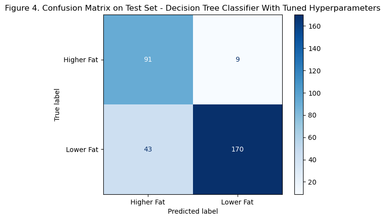

```
              precision    recall  f1-score   support

  higher fat     0.6791    0.9100    0.7778       100
   lower fat     0.9497    0.7981    0.8673       213

    accuracy                         0.8339       313
   macro avg     0.8144    0.8541    0.8226       313
weighted avg     0.8633    0.8339    0.8387       313
```

# Discussion

I chose hyperparameter tuning based on recall score for the purpose of my project. The model’s (recall) score is 0.9100 on the test set. The equation to manually calculate this is shown below. There are nine false negatives and 100 actual positives, which is derived from the addition of 91 and nine. The macro-average, calculated by assigning equal weight to “higher fat” and “lower fat,” is 0.8541.

[figure not shown]

Figure 5. Recall Equation. From “Module 7,” by University of British Columbia.

The accuracy metric calculates the ratio of correct predictions to total predictions. The total correct predictions include TP and TN, and the total predictions in this project amount to 313. 261 divided by 313 is 0.8339. Another method is using accuracy_score function as shown below. The dummy score is 0.5144 and the accuracy score of the model on the test set is 0.8339.

```
0.8339
```

The model’s score of 0.91 surpasses my anticipated value of 0.80 by 11%. A few intriguing modifications for future iterations of this project involve addressing the data imbalance using an alternate approach: a) specifying “stratify” argument in the “train_test_split” function or b) using “StratifiedKFold” function for cross-validation. Furthermore, utilizing Random Forest Classifier model may yield good results. It might be worth considering imputing the dropped columns to assess their impact on the final test score. The model performed exceptionally well on the test set and could be deployed. This suggests that decision trees might be effective in handling mildly imbalanced datasets.

# References

Cheese.com - World’s Greatest Cheese Resource. (n.d.). https://www.cheese.com/

The difference between farmstead, Artisanal & dairy cheeses. Cheese Origin. (2022, March 9). https://cheeseorigin.com/farmstead-artisanal-dairy/

Gouvernement du Canada. (2022, May 3). Eat Protein Foods. Canada Food Guide. https://food-guide.canada.ca/en/healthy-eating-recommendations/make-it-a-habit-to-eat-vegetables-fruit-whole-grains-and-protein-foods/eat-protein-foods/

Overfitting and Underfitting. Introduction to Machine Learning. (n.d.-a). https://ml-learn.mds.ubc.ca/module3/over_under.png

Recall Equation. Introduction to Machine Learning. (n.d.-b). https://ml-learn.mds.ubc.ca/module7/recall.png

Statista Market Insights. (n.d.). Cheese - canada: Statista market forecast. Statista. https://www.statista.com/outlook/cmo/food/dairy-products-eggs/cheese/canada